# SFB 1036 Course on Data Analysis: Lesson 5

Simon Anders

## Exploring data from a drug perturbation experiment in 384-well format

### The experiment

This is data curtesy of Tobias Roider from [Sascha Dietrich](https://www.embl.de/mmpu/mmpu/research_groups/systems_medicine_of_cancer_drugs/index.html)’s group at [MMPU](https://www.embl.de/mmpu/mmpu/). For a small pilot study, Tobias took primary cell samples from the lymph nodes of five patients suffering from lymphoma. He spread the cells from each patient over one 384-well plate and copied aliquots from a drug master plate over these, incubated them, then checked the number of remaining viable cells in each well with a flourescence-based ATP-sensitive readout. We have six files, five CSV from the plate reader, and one Excel file with the information on the layout of the drug master plate.

If you want to redo this analysis, you can find the six files here: lymphoma_data.zip.

# Reading in the plate files.

```r
library( tidyverse )
read_csv( "Patient_1.csv", skip=5, n_max=16 )
```

| X1 | 1 | 2 | 3 | 4 | 5 | 6 | 7 | 8 | 9 | 10 | 11 | 12 | 13 | 14 | 15 | 16 | 17 | 18 | 19 | 20 | 21 | 22 | 23 | 24 |
| --- | --- | --- | --- | --- | --- | --- | --- | --- | --- | --- | --- | --- | --- | --- | --- | --- | --- | --- | --- | --- | --- | --- | --- | --- |
| A | 5355440 | 639190 | 939650 | 5103660 | 5055260 | 4646200 | 5684710 | 4975540 | 5523140 | 4987510 | 5642530 | 5134460 | 6433490 | 5322830 | 5729100 | 5395070 | 5567770 | 5210210 | 5621140 | 5539410 | 4474470 | 4948790 | 4362590 | 4360960 |
| B | 4815410 | 5096240 | 5367640 | 3721820 | 4515230 | 6252840 | 4973910 | 5250930 | 5333730 | 4939960 | 5151510 | 5419520 | 5173490 | 5214760 | 5306830 | 5140250 | 5232880 | 5098290 | 4949880 | 5065220 | 4845220 | 2107740 | 1831870 | 4524740 |
| C | 3513990 | 4803050 | 5593220 | 3427060 | 3771160 | 3986640 | 4658140 | 4409830 | 1721560 | 4880760 | 3254020 | 4820220 | 6095610 | 5118710 | 5526210 | 5298690 | 5338820 | 5266800 | 5021280 | 4622410 | 4389720 | 4511910 | 1100500 | 4381570 |
| D | 5303860 | 5278300 | 5526100 | 5559100 | 5696420 | 5352190 | 5381120 | 5354890 | 5660090 | 5587780 | 6282320 | 6394350 | 5327120 | 5525950 | 6202090 | 5362890 | 6408700 | 5445620 | 4956460 | 5439930 | 5011520 | 4208390 | 4725830 | 4915680 |
| E | 943010 | 4802730 | 5411860 | 4029430 | 5502530 | 4177640 | 5252250 | 4689770 | 5576180 | 243290 | 889320 | 5137980 | 3498560 | 4893380 | 5221030 | 3554610 | 3924420 | 3403060 | 5413830 | 3439290 | 5026250 | 4201050 | 4857480 | 3675340 |
| F | 5400910 | 5499880 | 4907240 | 5536760 | 4640170 | 4846090 | 1622250 | 5221910 | 2656570 | 5119310 | 5478350 | 5395460 | 5918060 | 5662640 | 5818810 | 5942690 | 5289300 | 5321310 | 4640690 | 3748500 | 5296240 | 4862550 | 5164780 | 4753170 |
| G | 5056450 | 4746180 | 2312310 | 4925330 | 4739980 | 854550 | 2071600 | 3292370 | 502360 | 3589110 | 6041250 | 4512330 | 5330810 | 5144910 | 6131610 | 3639950 | 4786940 | 4797480 | 5636810 | 5131320 | 5294050 | 4804270 | 2061330 | 4943710 |
| H | 4740760 | 4976900 | 1420530 | 5510670 | 4310220 | 5086950 | 3468910 | 4772600 | 5416740 | 2889480 | 3210530 | 5294270 | 5123880 | 5571180 | 4987830 | 5127740 | 5296190 | 6267710 | 5412160 | 5486100 | 5303010 | 4937770 | 4634830 | 5415700 |
| I | 5783610 | 4163870 | 5582320 | 2191990 | 3516690 | 460780 | 2966690 | 5052020 | 5982360 | 5464570 | 5381730 | 4967890 | 4458150 | 3701540 | 5679610 | 5227670 | 4981450 | 5055560 | 5388210 | 5088290 | 1869870 | 4508010 | 4917640 | 4672820 |
| J | 3889850 | 4683130 | 1347460 | 1201540 | 3569640 | 5009450 | 3945940 | 5892850 | 6167920 | 6545430 | 5915910 | 5579190 | 5238070 | 6761390 | 5506660 | 4560540 | 3962540 | 3244260 | 5270070 | 5707570 | 4373710 | 4921090 | 4857140 | 5001960 |

[output cut: 6 more lines]

To make it easier to work with this data, we transform it from a wide table to a long table. In a “long table” (or, “tidy table” in the tidyverse nomenclature), every table row contains only data on one “object”. (Here, each well is an object.)

```r
read_csv( "Patient_1.csv", skip=5, n_max=16 ) %>%
   rename( "plate_row" = "X1") %>%
   gather( "plate_col", "intensity", -plate_row )
```

| plate_row | plate_col | intensity |
| --- | --- | --- |
| A | 1 | 5355440 |
| B | 1 | 4815410 |
| C | 1 | 3513990 |
| D | 1 | 5303860 |
| E | 1 | 943010 |
| F | 1 | 5400910 |
| G | 1 | 5056450 |
| H | 1 | 4740760 |
| I | 1 | 5783610 |
| J | 1 | 3889850 |

[output cut: 374 more lines]

Such a table is useful, for example, for plotting with ggplot:

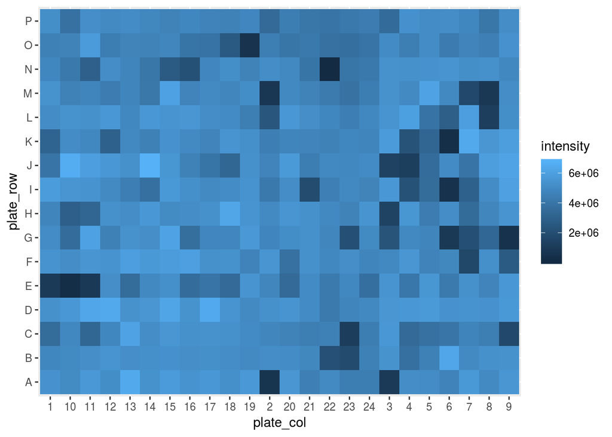

```r
read_csv( "Patient_1.csv", skip=5, n_max=16 ) %>%
   rename( "plate_row" = "X1") %>%
   gather( "plate_col", "intensity", -plate_row ) %>%
ggplot +
   geom_tile( aes( x = plate_col, y = plate_row, fill = intensity ) )
```

The plate is not rendered in the right order. Let’s fix this by reversing the rows and making clear to R that the columns should be sorted as numbers, not by alphabet. Also, let’s use log2 values for intensity and add white borders to the tiles. The `coord_fixed` ensures that x and y axis are scaled the same and hence the wells appear as squares.

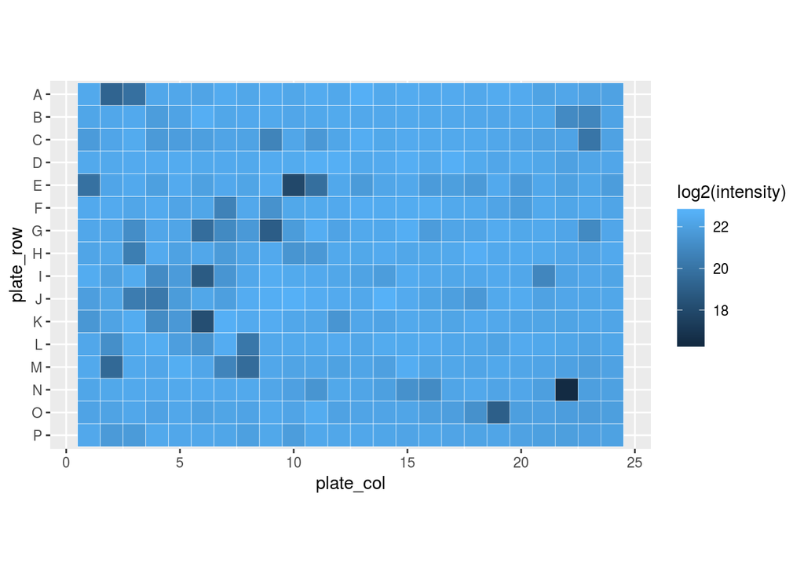

```r
read_csv( "Patient_1.csv", skip=5, n_max=16 ) %>%
   rename( "plate_row" = "X1") %>%
   gather( "plate_col", "intensity", -plate_row ) %>%
   mutate( plate_row = fct_rev( plate_row) ) %>%
   mutate( plate_col = as.integer(plate_col) ) %>%
ggplot +
   geom_tile( aes( x = plate_col, y = plate_row, fill = log2(intensity) ), color="white" ) +
   coord_fixed()
```

We want to work with all 5 plates, to let’s write a function which takes a patient number, read the file and produces a long table

```r
read_plate <- function( patient_number ) {
   filename <- str_c( "Patient_", patient_number, ".csv" )
   read_csv( filename, skip=5, n_max=16 ) %>%
   rename( "plate_row" = "X1") %>%
   gather( "plate_col", "intensity", -plate_row ) %>%
   mutate( plate_col = as.integer(plate_col) ) %>%
   add_column( plate_number = patient_number, .before="plate_row" )
}
```

We can call this function with a number

```r
read_plate( 2 )
```

| plate_number | plate_row | plate_col | intensity |
| --- | --- | --- | --- |
| 2 | A | 1 | 2621200 |
| 2 | B | 1 | 2930580 |
| 2 | C | 1 | 2394970 |
| 2 | D | 1 | 3055060 |
| 2 | E | 1 | 1377460 |
| 2 | F | 1 | 3061550 |
| 2 | G | 1 | 2945980 |
| 2 | H | 1 | 2936480 |
| 2 | I | 1 | 3046780 |
| 2 | J | 1 | 2647200 |

[output cut: 374 more lines]

We want to call this function for all five patients, i.e., for each of these values:

```r
1:5
```

```
## [1] 1 2 3 4 5
```

(`1:5` just returns the numbers from 1 to 5.)

The `map_dfr` function calls a given function for each element, expects this function to return a data frame (i.e., a table or tibble) and then combined all the returned tables row-wise (i.e., one below the other). There is also `map_dfc`, which combnines them column-wise (i.e., side-by-side). We use it to call our `read_plate` function for all five plates.

```r
tbl <- map_dfr( 1:5, read_plate )
tbl
```

| plate_number | plate_row | plate_col | intensity |
| --- | --- | --- | --- |
| 1 | A | 1 | 5355440 |
| 1 | B | 1 | 4815410 |
| 1 | C | 1 | 3513990 |
| 1 | D | 1 | 5303860 |
| 1 | E | 1 | 943010 |
| 1 | F | 1 | 5400910 |
| 1 | G | 1 | 5056450 |
| 1 | H | 1 | 4740760 |
| 1 | I | 1 | 5783610 |
| 1 | J | 1 | 3889850 |

[output cut: 1910 more lines]

Now, we have all data in hand and can plot one big overview plot

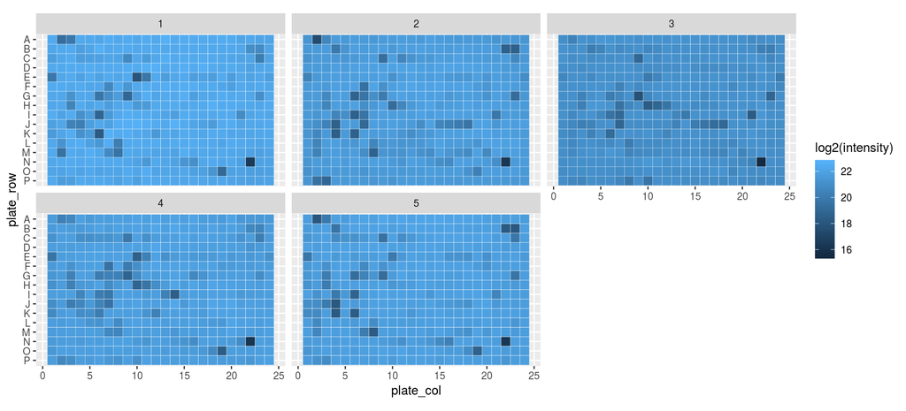

```r
tbl %>%
   mutate( plate_row = fct_rev( plate_row ) ) %>%
ggplot +
   geom_tile( aes( x = plate_col, y = plate_row, fill = log2(intensity) ), color="white" ) +
   facet_wrap( ~ plate_number ) + coord_fixed()
```

## Plate annotation

Next, let’s read in the Excel file with the well annotation

```r
readxl::read_excel( "PlateAnnotation.xlsx" )
```

| ..1 | Row | Row_in_number | Column | Position | Drug | Drug_Concentration | Conc_mikroMolar |
| --- | --- | --- | --- | --- | --- | --- | --- |
| 1 | A | 1 | 1 | A1 | DMSO | 0 | 0.0000e+00 |
| 2 | A | 1 | 2 | A2 | Passionfruit | C1 | 1.5000e+01 |
| 3 | A | 1 | 3 | A3 | Passionfruit | C2 | 3.0000e+00 |
| 4 | A | 1 | 4 | A4 | DMSO | 0 | 0.0000e+00 |
| 5 | A | 1 | 5 | A5 | Passionfruit | C3 | 6.0000e-01 |
| 6 | A | 1 | 6 | A6 | Passionfruit | C4 | 1.2000e-01 |
| 7 | A | 1 | 7 | A7 | Passionfruit | C5 | 2.4000e-02 |
| 8 | A | 1 | 8 | A8 | Plum | C1 | 1.5000e+01 |
| 9 | A | 1 | 9 | A9 | DMSO | 0 | 0.0000e+00 |
| 10 | A | 1 | 10 | A10 | Plum | C2 | 3.0000e+00 |

[output cut: 374 more lines]

As this is data from an unpublished experiment, we did not want to make the content of the drug master plate public. Therefore, I have replaced all the drug names in the “Drug” column with names of fruits from [this list](https://simple.wikipedia.org/wiki/List_of_fruits), only leaving the value “DMSO” as it was.

Apart from now having strange drug names, the table is a bit redundant, an has lengthy column names. Let’s clean this up a bit:

```r
readxl::read_excel( "PlateAnnotation.xlsx" ) %>%
   select(
      plate_row = Row,
      plate_col = Column,
      drug = Drug,
      conc_level = Drug_Concentration,
      conc_uMol = Conc_mikroMolar ) %>%
   mutate( conc_uMol = as.numeric( conc_uMol ) ) %>%
   mutate( plate_col = as.integer(plate_col) ) ->
      layout
layout
```

| plate_row | plate_col | drug | conc_level | conc_uMol |
| --- | --- | --- | --- | --- |
| A | 1 | DMSO | 0 | 0.0000e+00 |
| A | 2 | Passionfruit | C1 | 1.5000e+01 |
| A | 3 | Passionfruit | C2 | 3.0000e+00 |
| A | 4 | DMSO | 0 | 0.0000e+00 |
| A | 5 | Passionfruit | C3 | 6.0000e-01 |
| A | 6 | Passionfruit | C4 | 1.2000e-01 |
| A | 7 | Passionfruit | C5 | 2.4000e-02 |
| A | 8 | Plum | C1 | 1.5000e+01 |
| A | 9 | DMSO | 0 | 0.0000e+00 |
| A | 10 | Plum | C2 | 3.0000e+00 |

[output cut: 374 more lines]

## Checking the control wells

Where are the control wells?

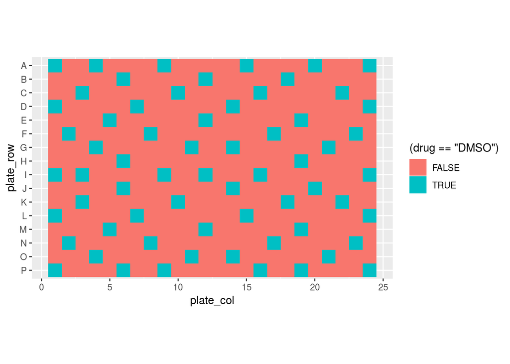

```r
layout %>%
mutate( plate_row = fct_rev( plate_row ) ) %>%
ggplot +
   geom_tile( aes( x=plate_col, y=plate_row, fill=(drug=="DMSO") ) ) +
   coord_fixed()
```

As you can see, care was taken to spread the control wells over the whole plate. This helps to check for spatial artifacts, as we will see in a minute.

How equal are the control wells? Let’s plot their intensity.

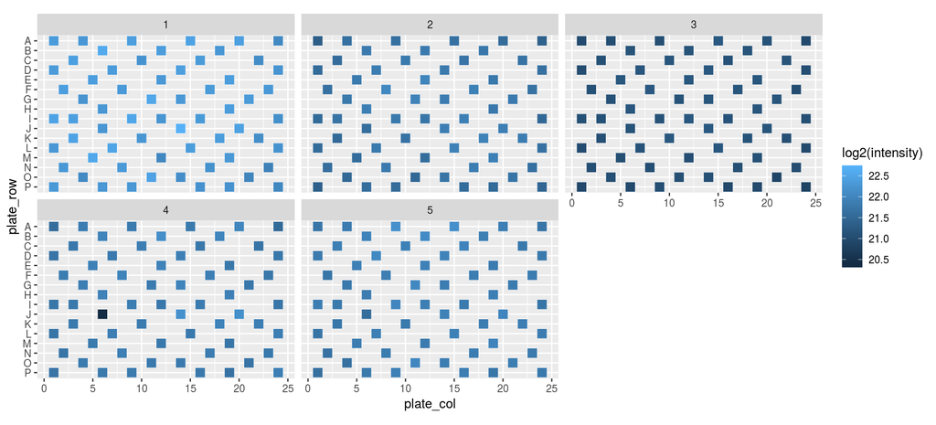

```r
tbl %>%
   left_join( layout ) %>%
   filter( drug == "DMSO" ) %>%
   mutate( plate_row = fct_rev( plate_row ) ) %>%
ggplot +
   geom_tile( aes( x = plate_col, y = plate_row, fill = log2(intensity) ), color="white" ) +
   facet_wrap( ~ plate_number ) + coord_fixed()
```

We mainly see differences between plates, but we want to see heterogeneity within the plates. To make this more visible, let’s divide the DMSO control wells of each plate by their median DMSO intensity, to get relative intensity wells (relative to the plate control median), so we call this new columns `rel_int`.

We also use the `scale_fill_gradient2` function to get a diverging color scale, centered at zero with white and showing gradients towards red for negative and towards blue for positive values. Such a diverging colour scale should always be used when visualizing data spreading around zero. As it would be nice to have the colour scale labelled on a natural scale, we replace `fill=log2(rel_int)` with simply `fill=rel_int` in the `aes` phrase, and instead specify the transformation in the colour scale specification: `trans="log2"`.

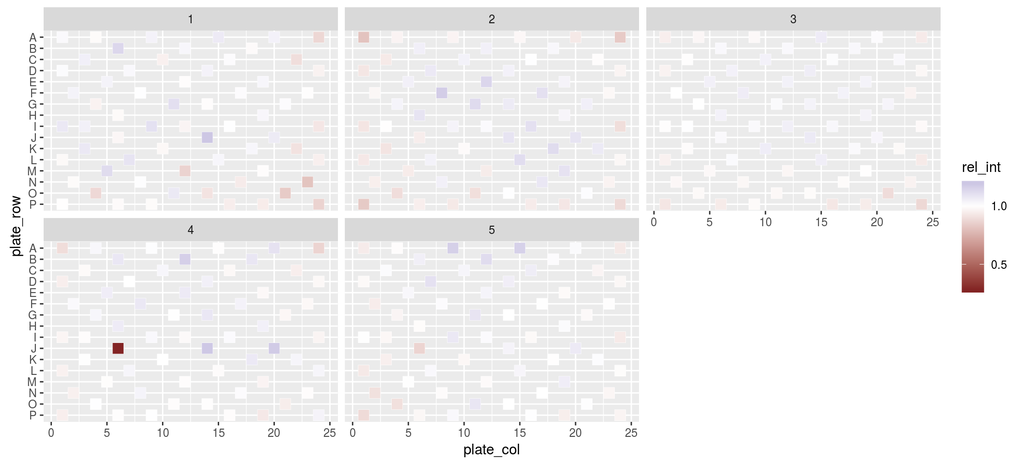

```r
tbl %>%
   left_join( layout ) %>%
   filter( drug == "DMSO" ) %>%
   group_by( plate_number ) %>%
   mutate( rel_int = intensity / median( intensity ) ) %>%
   mutate( plate_row = fct_rev( plate_row ) ) %>%
ggplot +
   geom_tile( aes( x = plate_col, y = plate_row, fill = rel_int ), color="white" ) +
   facet_wrap( ~ plate_number ) + coord_fixed() +
   scale_fill_gradient2( trans="log2")
```

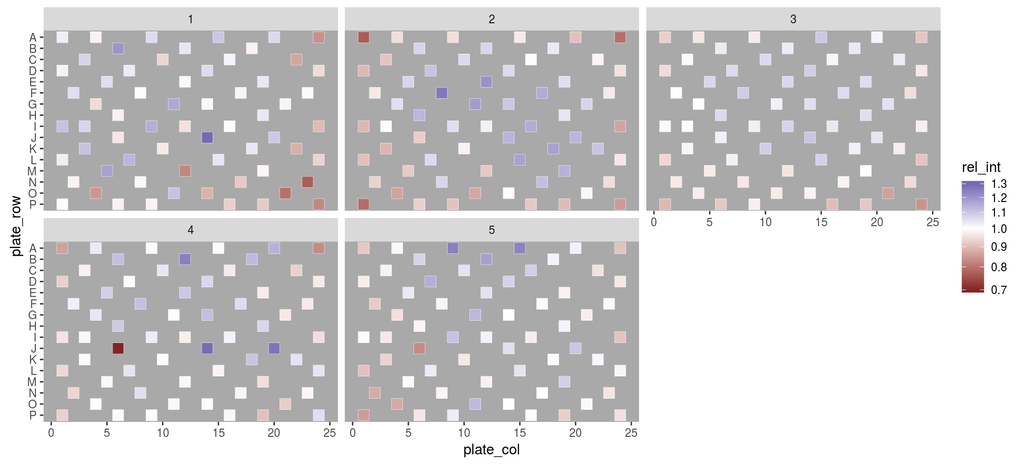

```r
tbl %>%
   left_join( layout ) %>%
   filter( drug == "DMSO" ) %>%
   group_by( plate_number ) %>%
   mutate( rel_int = intensity / median( intensity ) ) %>%
   mutate( plate_row = fct_rev( plate_row ) ) %>%
ggplot +
   geom_tile( aes( x = plate_col, y = plate_row, fill = rel_int ), color="white" ) +
   facet_wrap( ~ plate_number ) +
   scale_fill_gradient2( trans="log2", limits=c(.7,1.3), oob=scales::squish,
      breaks=c( .7, .8, .9, 1, 1.1, 1.2, 1.3 ) ) +
   coord_fixed() +
   theme( panel.background = element_rect("darkgray"), panel.grid = element_blank() )
```

Is this spread small enough to ignore the spatial artifacts? This may be easier to judge using a beeswarm plot.

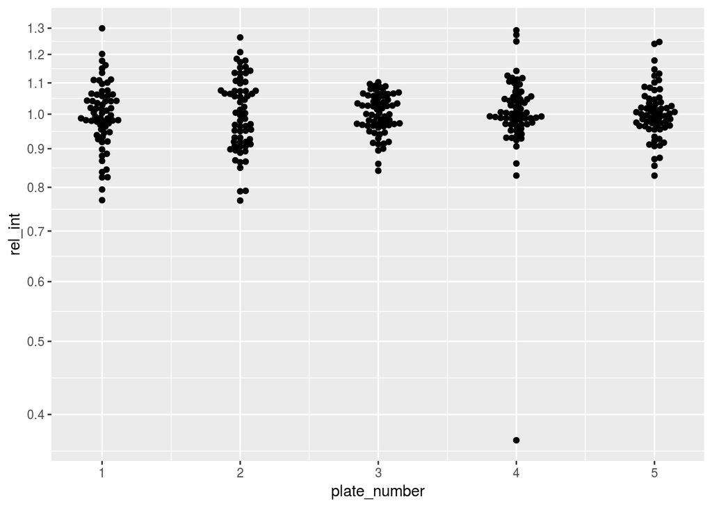

```r
tbl %>%
   left_join( layout ) %>%
   filter( drug == "DMSO" ) %>%
   group_by( plate_number ) %>%
   mutate( rel_int = intensity / median( intensity ) ) %>%
ggplot +
   ggbeeswarm::geom_beeswarm( aes( x = plate_number, y = rel_int ) ) +
   scale_y_continuous( trans="log2", breaks = seq( 0, 2, by=.1 ) )
```

## Drug response curves

Enough looking at control wells

Let’s just use the median of each plate’s control wells as normalization reference

```r
tbl %>%
   left_join( layout ) %>%
   filter( drug=="DMSO" ) %>%
   group_by( plate_number ) %>%
   summarise( median_dmso_intensity = median( intensity ) ) ->
      ctrl_int_tbl
ctrl_int_tbl
```

| plate_number | median_dmso_intensity |
| --- | --- |
| 1 | 5203590 |
| 2 | 3411870 |
| 3 | 2237970 |
| 4 | 3669590 |
| 5 | 3782755 |

Now, use this to normalize our data

```r
tbl %>%
   left_join( layout ) %>%
   left_join( ctrl_int_tbl ) %>%
   mutate( rel_int = intensity / median_dmso_intensity ) ->
      tbl2
tbl2
```

| plate_number | plate_row | plate_col | intensity | drug | conc_level | conc_uMol | median_dmso_intensity | rel_int |
| --- | --- | --- | --- | --- | --- | --- | --- | --- |
| 1 | A | 1 | 5355440 | DMSO | 0 | 0.0000e+00 | 5203590 | 1.02918178 |
| 1 | B | 1 | 4815410 | Soursop | C3 | 6.0000e-01 | 5203590 | 0.92540150 |
| 1 | C | 1 | 3513990 | Soursop | C2 | 3.0000e+00 | 5203590 | 0.67530109 |
| 1 | D | 1 | 5303860 | DMSO | 0 | 0.0000e+00 | 5203590 | 1.01926939 |
| 1 | E | 1 | 943010 | Soursop | C1 | 1.5000e+01 | 5203590 | 0.18122296 |
| 1 | F | 1 | 5400910 | Yuzu | C5 | 8.0000e-03 | 5203590 | 1.03791997 |
| 1 | G | 1 | 5056450 | Yuzu | C4 | 4.0000e-02 | 5203590 | 0.97172337 |
| 1 | H | 1 | 4740760 | Yuzu | C3 | 2.0000e-01 | 5203590 | 0.91105564 |
| 1 | I | 1 | 5783610 | DMSO | 0 | 0.0000e+00 | 5203590 | 1.11146535 |
| 1 | J | 1 | 3889850 | Yuzu | C2 | 1.0000e+00 | 5203590 | 0.74753199 |

[output cut: 1910 more lines]

Let’s plot one drug, say “Passionfruit”

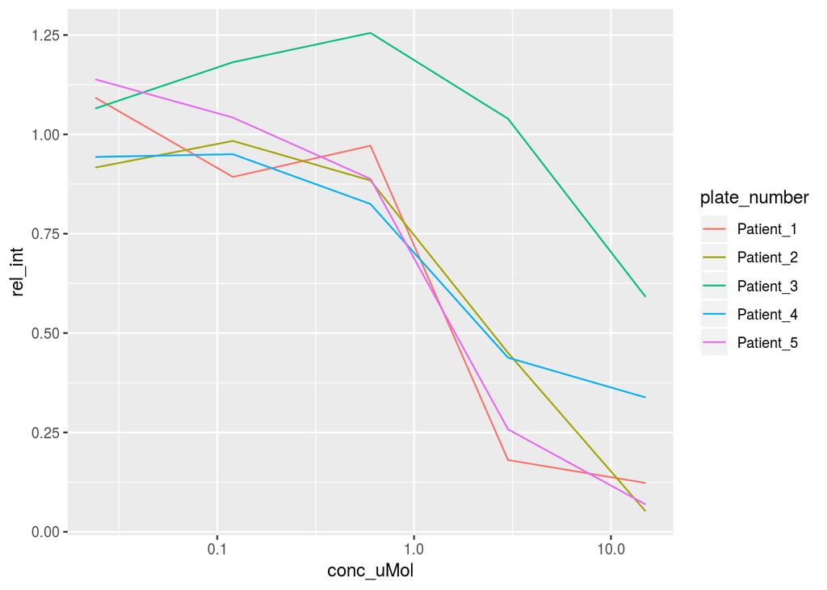

```r
tbl2 %>%
   filter( drug == "Passionfruit") %>%
   mutate( plate_number = str_c( "Patient_", plate_number ) ) %>%
ggplot +
   geom_line( aes( x = conc_uMol, y = rel_int, col = plate_number ) ) +
   scale_x_log10()
```

By putting a `for` loop around these commands, we can make a PDF file with one such plot per page, one for each drugs.

We first get the names of all drugs

```r
layout %>%
   filter( drug != "DMSO" ) %>%
   pull( "drug" ) %>%
   unique ->
      drugs
drugs
```

```
##  [1] "Passionfruit"      "Plum"              "Apricot"
##  [4] "Dragonfruit"       "Soursop"           "Star fruit"
##  [7] "Olive"             "Fig"               "Apple"
## [10] "Purple mangosteen" "Plantain"          "Mulberry"
## [13] "Currant"           "Orange"            "Mangosteen"
## [16] "Blood orange"      "Bilberry"          "Raspberry"
## [19] "Nance"             "Blackcurrant"      "Honeyberry"
## [22] "Watermelon"        "Cucumber"          "Yuzu"
## [25] "Jabuticaba"        "White sapote"      "Buddha's hand"
## [28] "Salmonberry"       "Black sapote"      "Mandarine"
## [31] "White currant"     "Papaya"            "Raisin"
## [34] "Marionberry"       "Cranberry"         "Date palm|Date"
## [37] "Plumcot"           "Mango"             "Redcurrant"
## [40] "Pear"              "Juniper berry"     "Jackfruit"
## [43] "Cantaloupe"        "Jostaberry"        "Guava"
## [46] "Surinam cherry"    "Persimmon"         "Damson"
## [49] "Goji berry"        "Clementine"        "Coconut"
## [52] "Chico fruit"       "Grape"             "Cherry"
## [55] "Feijoa"            "Salal"             "Kiwano"
## [58] "Peach"             "Tamarind"          "Blackberry"
## [61] "Blueberry"         "Star apple"        "Lychee"
## [64] "Strawberry"
```

Now, we open a PDF file for writing (`pdf`), run the `for` loop, and close the PDF file (`dev.off`). The `pdf` command means that all subsequent plotting commands should result in the produced plot not being displayed on the screen as usual but rather added as a new page to the PDF file until this rerouting is switched off again with `dev.off`.

The for loop runs its body (the part in curly braces) once each of the drugs in the vector `drugs`, by putting the value of each drug into the variable `dr` (`for ( dr in drugs )`) and then runs the commands. These produce one plot. Whenever you use ggplot within a function or a block, you have to surround the whole ggplot command with parenthesis and hand it to `print` (for reasons we dobn’t want to go into now), as otherwise nothing gets plotted.

```r
# start a PDF file
pdf( "dose_resp_curves.pdf" )

# Go through the list of drugs
for( dr in drugs ) {
   (tbl2 %>%
      filter( drug == dr ) %>%
      mutate( plate_number = str_c( "Patient_", plate_number ) ) %>%
   ggplot +
      geom_line( aes( x = conc_uMol, y = rel_int, col = plate_number ) ) +
      scale_x_log10() +
      ggtitle( dr ) ) %>% print
}

# close the PDF
dev.off()
```

You can look at the PDF thus produced here: dose_resp_curves.pdf

## Getting AUC values

For each drug and each patient, we have five response values in the `rel_int` column, namely the responses to the five concentrations in which the drug is present on the master plate. Let us simply average over these to get one single value. In a way, this is roughly the same as calculating the area under the dose response curve.

```r
tbl2 %>%
   filter( drug != "DMSO" ) %>%
   group_by( plate_number, drug ) %>%
   summarise( mean_viab = mean( rel_int ) )
```

| plate_number | drug | mean_viab |
| --- | --- | --- |
| 1 | Apple | 0.5620512 |
| 1 | Apricot | 1.0422428 |
| 1 | Bilberry | 1.0906224 |
| 1 | Blackberry | 0.9031180 |
| 1 | Blackcurrant | 0.9118808 |
| 1 | Black sapote | 1.0048951 |
| 1 | Blood orange | 1.1242877 |
| 1 | Blueberry | 0.6031344 |
| 1 | Buddha's hand | 0.7791521 |
| 1 | Cantaloupe | 1.1569436 |

[output cut: 310 more lines]

We can use the `spread` fucntion to turn this long table into a wide table. This is the opposite of `gather`, which we have used further up to turn a wide table into a long one. Hence we add one line to the previous code chunk.

```r
tbl2 %>%
   filter( drug != "DMSO" ) %>%
   group_by( plate_number, drug ) %>%
   summarise( mean_viab = mean( rel_int ) ) %>%
   spread( plate_number, mean_viab )
```

| drug | 1 | 2 | 3 | 4 | 5 |
| --- | --- | --- | --- | --- | --- |
| Apple | 0.5620512 | 0.5024576 | 0.7448491 | 0.5766846 | 0.4617407 |
| Apricot | 1.0422428 | 0.9323655 | 1.0457924 | 1.0102802 | 1.1376190 |
| Bilberry | 1.0906224 | 1.1949816 | 0.8827831 | 1.0272608 | 0.9978405 |
| Blackberry | 0.9031180 | 0.9153274 | 0.9585928 | 0.9555345 | 0.9849007 |
| Blackcurrant | 0.9118808 | 1.0666942 | 0.9661327 | 1.0413223 | 0.8890081 |
| Black sapote | 1.0048951 | 1.0733791 | 0.9823822 | 1.0030341 | 1.0314541 |
| Blood orange | 1.1242877 | 1.1626094 | 0.9071811 | 1.1148978 | 1.0449368 |
| Blueberry | 0.6031344 | 0.8027615 | 0.9612890 | 0.6184696 | 0.6523558 |
| Buddha's hand | 0.7791521 | 0.8957545 | 0.9180749 | 0.6496263 | 0.8157282 |
| Cantaloupe | 1.1569436 | 1.0069223 | 0.8863148 | 1.0394060 | 0.9973789 |

[output cut: 54 more lines]

To plot this as a heatmap, we have to turn it from a tidyverse tibble into a matrix, because the heatmap plotting functions of R don’t work well with tidyverse objects. The `as.matrix` function does this. Before, we turn the column with the drug names into row names for the matrix, so that the matrix itself contains only numbers.

```r
tbl2 %>%
   filter( drug != "DMSO" ) %>%
   group_by( plate_number, drug ) %>%
   summarise( mean_viab = mean( rel_int ) ) %>%
   spread( plate_number, mean_viab ) %>%
   column_to_rownames( "drug" ) %>%
   as.matrix ->
      responseMatrix

responseMatrix[ 1:10, ]
```

```
##                       1         2         3         4         5
## Apple         0.5620512 0.5024576 0.7448491 0.5766846 0.4617407
## Apricot       1.0422428 0.9323655 1.0457924 1.0102802 1.1376190
## Bilberry      1.0906224 1.1949816 0.8827831 1.0272608 0.9978405
## Blackberry    0.9031180 0.9153274 0.9585928 0.9555345 0.9849007
## Blackcurrant  0.9118808 1.0666942 0.9661327 1.0413223 0.8890081
## Black sapote  1.0048951 1.0733791 0.9823822 1.0030341 1.0314541
## Blood orange  1.1242877 1.1626094 0.9071811 1.1148978 1.0449368
## Blueberry     0.6031344 0.8027615 0.9612890 0.6184696 0.6523558
## Buddha's hand 0.7791521 0.8957545 0.9180749 0.6496263 0.8157282
## Cantaloupe    1.1569436 1.0069223 0.8863148 1.0394060 0.9973789
```

Now, we can use the `pheatmap` function from Raivo Kolde’s “pretty heatmaps” package to make our heatmap. Have a look at the help page for `pheatmap` to see its many options. We just use one, to tell it to perform hierarchical clustering on our drugs not using the usual Euclidean distance but correlation distance, which works better for drug response data.

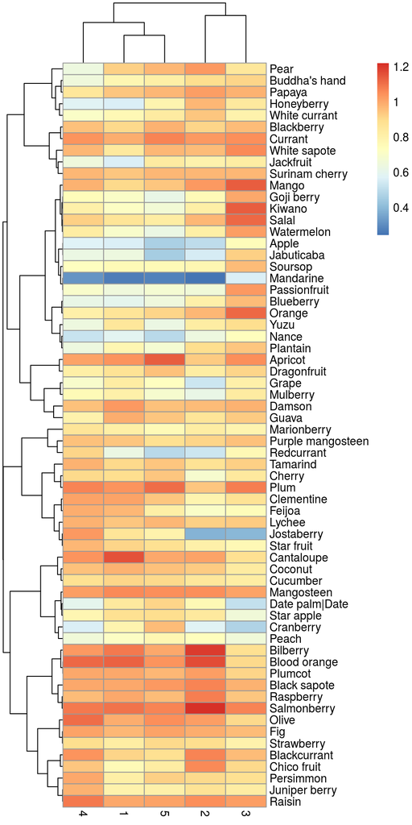

```r
library( pheatmap )
pheatmap( responseMatrix, clustering_distance_rows = "correlation" )
```

We can also look directly at the correlation matrix. In earlier lessons, we have used the `cor` function to calculate the correlation between to vectors. Here, we give it a matrix, and it calculates a matrix of correlations between all the matrix columns. As we want to see the correlation between rows, we have to transpose the matrix first, with `t`.

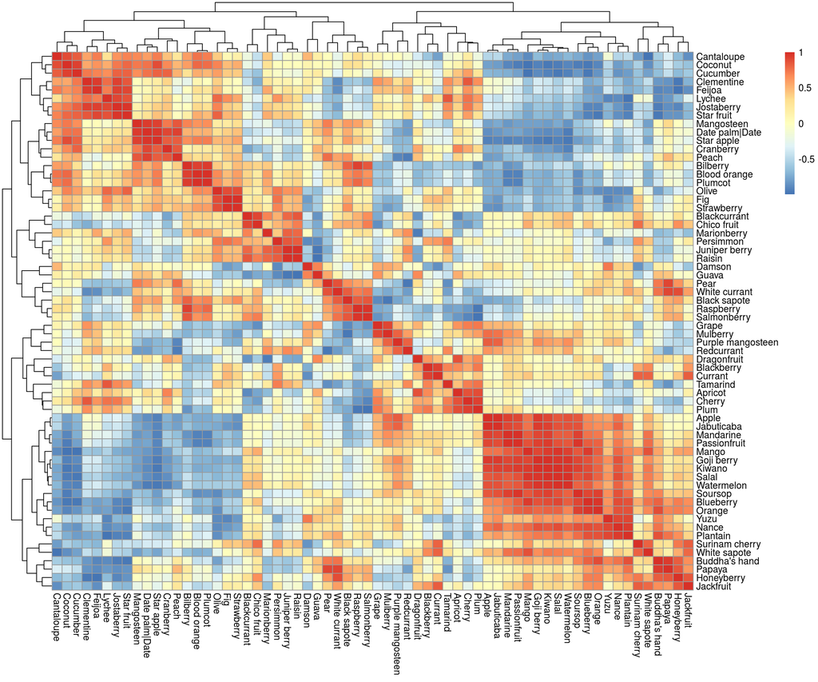

```r
pheatmap( cor( t(responseMatrix) ) )
```

This correlation heatmap is quite noisy, simply because we have samples from only five patients. However, even now, you would see (if you had the real drug names instead of fruit names) that the red squares along the diagonal tend to correspond to drugs with related mode of action. A somewhat larger cohort can hence give a surprising amount of details. See, e.g., Figure 3 of this paper by Dietrich et al.